# Fitness Records Analysis and Prediction with Machine Learning

In this project, I will analyse the data about fitness metrics and build a machine learning model.

Attributes:

- Duration: Length of the workout session (in minutes)
- Pulse: Average heart rate during the session (in beats per minute)
- Maxpulse: Maximum heart rate reached during the session (in beats per minute)
- Calories: Estimated calories burned during the session

## 1. Cleaning data

```python
# Import libraries

# For data manipulation
import pandas as pd
import numpy as np

# For creating data visualisations
import matplotlib.pyplot as plt
import seaborn as sns

# For machine learning models
from sklearn.linear_model import LinearRegression # For building linear regression model
from sklearn.tree import DecisionTreeRegressor # For building decision tree model
from sklearn.model_selection import train_test_split
from sklearn.metrics import mean_squared_error, r2_score
```

```python
# Load data into a dataframe
df = pd.read_csv("fitness_data.csv")
```

```python
# Check the shape of the dataset
df.shape
```

```
(169, 4)
```

```python
# Check info about the dataset
df.info()
```

```
<class 'pandas.core.frame.DataFrame'>
RangeIndex: 169 entries, 0 to 168
Data columns (total 4 columns):
 #   Column    Non-Null Count  Dtype
---  ------    --------------  -----
 0   Duration  169 non-null    int64
 1   Pulse     169 non-null    int64
 2   Maxpulse  169 non-null    int64
 3   Calories  164 non-null    float64
dtypes: float64(1), int64(3)
memory usage: 5.4 KB
```

```python
# Generate descriptive statistics
df.describe()
```

|  | Duration | Pulse | Maxpulse | Calories |
| --- | --- | --- | --- | --- |
| count | 169.000000 | 169.000000 | 169.000000 | 164.000000 |
| mean | 63.846154 | 107.461538 | 134.047337 | 375.790244 |
| std | 42.299949 | 14.510259 | 16.450434 | 266.379919 |
| min | 15.000000 | 80.000000 | 100.000000 | 50.300000 |
| 25% | 45.000000 | 100.000000 | 124.000000 | 250.925000 |
| 50% | 60.000000 | 105.000000 | 131.000000 | 318.600000 |
| 75% | 60.000000 | 111.000000 | 141.000000 | 387.600000 |
| max | 300.000000 | 159.000000 | 184.000000 | 1860.400000 |

### Comments

- Data types seem to be correct
- There are 5 rows with missing values in the Calories column

```python
# See the columns with missing values
df[df.Calories.isna()]
```

|  | Duration | Pulse | Maxpulse | Calories |
| --- | --- | --- | --- | --- |
| 17 | 45 | 90 | 112 | NaN |
| 27 | 60 | 103 | 132 | NaN |
| 91 | 45 | 107 | 137 | NaN |
| 118 | 60 | 105 | 125 | NaN |
| 141 | 60 | 97 | 127 | NaN |

### Comments

Since the Calories column is important for the analysis, I will remove the columns with missing values

```python
# Removing columns with missing values
df = df[~ df.Calories.isna()]

# Make sure there are no missing values now
df.isna().sum()
```

```
Duration    0
Pulse       0
Maxpulse    0
Calories    0
dtype: int64
```

```python
# Check for the duplicates
df[df.duplicated()]
```

|  | Duration | Pulse | Maxpulse | Calories |
| --- | --- | --- | --- | --- |
| 36 | 60 | 102 | 127 | 300.0 |
| 37 | 60 | 100 | 120 | 300.0 |
| 38 | 60 | 100 | 120 | 300.0 |
| 40 | 45 | 90 | 112 | 180.1 |
| 71 | 60 | 109 | 153 | 387.6 |
| 113 | 45 | 100 | 120 | 225.3 |
| 155 | 60 | 111 | 151 | 368.5 |

### Comments

Since it is highly unlikely that all 4 metrics can be the same for different exercise sessions, I will considerem them as duplicates and remove them

```python
# Removing duplicates
df = df[~ df.duplicated()]

# Check that duplicated were removed
df.duplicated().sum()
```

```
0
```

## 2. Data exploration and visualisation

### Comments

I will visualise the relationship between duration of the work-out session and calories burnt

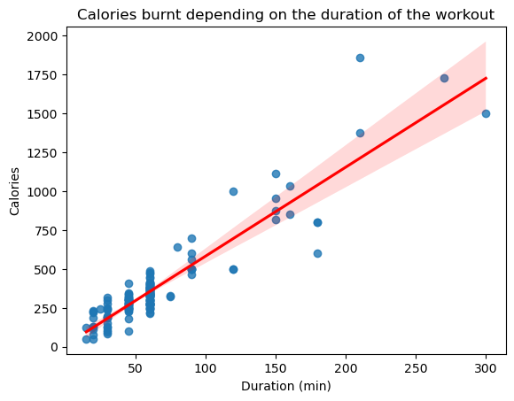

```python
sns.regplot(data = df, x = 'Duration', y = 'Calories', line_kws={'color': 'red'})
plt.xlabel('Duration (min)')
plt.title('Calories burnt depending on the duration of the workout')
plt.show()
```

### Comments

The above plot shows that in general the greater the duration the larger the amount of calories burnt

### Comments

I will visualise values of the average and maximum pulse during sessions

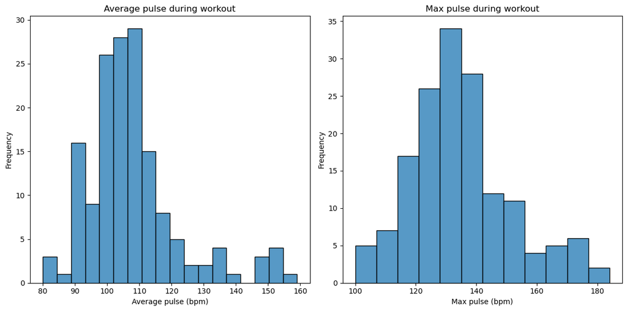

```python
# Create subplots
fig, ax = plt.subplots(1, 2, figsize = (12, 6))  # 1 row, 2 columns

# Average pulse plot
sns.histplot(data = df, x = 'Pulse', ax = ax[0])
ax[0].set_title('Average pulse during workout')
ax[0].set_xlabel('Average pulse (bpm)')
ax[0].set_ylabel('Frequency')

# Max pulse plot
sns.histplot(data = df, x = 'Maxpulse', ax = ax[1])
ax[1].set_title('Max pulse during workout')
ax[1].set_xlabel('Max pulse (bpm)')
ax[1].set_ylabel('Frequency')

# Adjust layout to prevent overlap
plt.tight_layout()
plt.show()
```

### Comments

Based on the above histograms, I can determine that:

- Most people have average pulse between 90-120 bpm
- The peak frequency for the Average pulse histogram is around 110 bpm
- Most people have max pulse between 115-145 bpm
- The peak frequency for the Max pulse histogram is around 125-135 bpm
- The average pulse during workouts tends to be lower than the maximum pulse, as expected
- Both plots exhibit normal-like distribution shapes, but the Max pulse histogram is more right-skewed compared to the Average pulse one

### Comments

I will create a correlation matrix to see the correlation coefficients between variables in the dataset

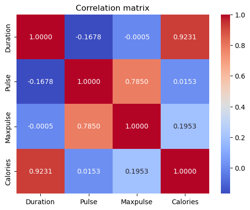

```python
# Create a correlation matrix and display it as a heatmap
correlation_matrix = df.corr()
sns.heatmap(correlation_matrix, annot = True, cmap = 'coolwarm', fmt = '.4f')
plt.title('Correlation matrix')
plt.show()
```

### Comments

Based on the heatmap above, I can determine that:

- The strongest correlation is between calories burnt and duration of the workout (92%)
- The weakest correlation is between max pulse and duration of the workout (-0.05%, which is almost 0%); however, the correlation between the average pulse and duration is stronger (-16.8%)
- The correlation between the average pulse and the calories burnt is very weak (1.5%); however, the correlation between the max pulse and the calories burnt is much stronger (19.5%)
- The correlation between the average pulse and max pulse is very strong (78.5%), meaning that the higher is the average pulse during the workout the higher is the max pulse

## 3. Creating machine learning models

### 3.1 Building a linear regression model

### Comments

I chose to create a linear regression model for predicting calories burnt because it is a simple, interpretable model that works well when both the target variable (calories burnt) and the features (duration, max pulse, and average pulse) are numeric. The model assumes a linear relationship between these variables, allowing me to understand how each feature contributes to the predicted calories. Linear regression serves as an excellent baseline model to evaluate the relationship between workout characteristics and calorie burnt.

I will split the dataset into:

- The training set (80%), which is used to fit the model
- And the testing set (20%), which is used to evaluate the model’s performance

```python
X = df[['Duration', 'Pulse', 'Maxpulse']] # Independent variables (features)
y = df['Calories'] # Dependent variable (target variable)
```

```python
# Split the dataset into training and test sets
X_train, X_test, y_train, y_test = train_test_split(X, y, test_size = 0.2, random_state = 42)
# random_state ensures that the data split is reproducible (the same random split each time teh code is run)
```

```python
# Initialise the model
lr_model = LinearRegression()
```

```python
# Train (fit) the model on the training set
lr_model.fit(X_train, y_train)
```

```
LinearRegression()
```

```python
# Make prediction to the test set to see how well the model performs on unseen data
y_pred_lr = lr_model.predict(X_test)
```

### 3.2 Evaluating the linear regression model

```python
# Evaluate the model using metrics such as mean squared error and R-squared

# Calculate the metrics
mse_lr = mean_squared_error(y_test, y_pred_lr)
r2_lr = r2_score(y_test, y_pred_lr)

# Print the metrics
print(f"Mean squared error for the linear regression model is: {mse_lr:.2f}")
print(f"R-squared for the linear regression model is: {r2_lr:.2f}")
```

```
Mean squared error for the linear regression model is: 6005.31
R-squared for the linear regression model is: 0.82
```

```python
# Analyse MSE, RMSE, and compare to the typical values of calories burnt in the dataset

rmse_lr = mse_lr ** 0.5  # Taking the square root of MSE to get RMSE

print(f"Root mean squared error is: {rmse_lr:.2f}")
print(f"Average calories burnt in the dataset: {df['Calories'].mean():.2f}")
print(f"Max calories burnt in the dataset: {df['Calories'].max():.2f}")
print(f"Min calories burnt in the dataset: {df['Calories'].min():.2f}")
```

```
Root mean squared error is: 77.49
Average calories burnt in the dataset: 379.41
Max calories burnt in the dataset: 1860.40
Min calories burnt in the dataset: 50.30
```

```python
# Print the model coefficients and intercept
print(f"Coefficients: {np.round(lr_model.coef_, 2)}")
print(f"Intercept: {np.round(lr_model.intercept_, 2)}")
```

```
Coefficients: [5.81 0.5  2.83]
Intercept: -427.5
```

### Comments

Interpretation of coefficients

- 5.81: This coefficient corresponds to the duration. It indicates that for each additional minute of duration, the model predicts an increase of approximately 5.81 calories burnt, holding the other variables constant
- 0.50: This coefficient corresponds to the average pulse. It suggests that for each additional bpm in the average pulse, the model predicts an increase of about 0.50 calories burnt, holding the other variables constant
- 2.83: This coefficient corresponds to the max pulse. It indicates that for each additional bpm in the max pulse, the model predicts an increase of approximately 2.83 calories burnt, keeping the other variables constant

Interpretation of intercept

- The intercept of -427.5 indicates the predicted calories burnt when all features (duration, average pulse, and max pulse) are at zero. In this context, the negative intercept does not have a meaningful interpretation, as having zero duration and pulses isn't realistic in a fitness context

Summary

I can determine that the linear regression model performed well, because since the RMSE is relatively small compared to the average calories burnt, indicating that the model has a reasonable predictive capability.

### 3.3 Building a decision tree model

### Comments

I will also build a decision tree model in order to see if it performs better than the linear regression model

```python
# Initialise the model
dt_model = DecisionTreeRegressor(max_depth = 3, random_state = 42) # max_depth is added to prevent overfitting
```

```python
# Train (fit) the model on the training set
dt_model.fit(X_train, y_train)
```

```
DecisionTreeRegressor(max_depth=3, random_state=42)
```

```python
# Make prediction to the test set to see how well the model performs on unseen data
y_pred_dt = dt_model.predict(X_test)
```

### 3.4 Evaluating the decision tree model

```python
# Evaluate the model using metrics such as mean squared error and R-squared

# Calculate the metrics
mse_dt = mean_squared_error(y_test, y_pred_dt)
r2_dt = r2_score(y_test, y_pred_dt)
rmse_dt = mse_dt ** 0.5  # Taking the square root of MSE to get RMSE

# Print the metrics
print(f"Mean squared error for the decision tree model is: {mse_dt:.2f}")
print(f"R-squared for the decision tree model is: {r2_dt:.2f}")
print(f"Root mean squared error is: {rmse_dt:.2f}")
```

```
Mean squared error for the decision tree model is: 10290.58
R-squared for the decision tree model is: 0.69
Root mean squared error is: 101.44
```

```python
# Compare results of both models

print(f"MSE_dt: {mse_dt:.2f}; MSE_lr: {mse_lr:.2f}")
print(f"R2_dt: {r2_dt:.2f}; R2_lr: {r2_lr:.2f}")
```

```
MSE_dt: 10290.58; MSE_lr: 6005.31
R2_dt: 0.69; R2_lr: 0.82
```

### 3.5 Comparing both models

Based on the results, I can determine that the linear regression model outperformed the decision tree model in terms of both MSE and R2. The differences in performance suggest that a more complex model like decision trees might not be necessary for this dataset.

### 3.6 Visualizing the performance of the best model (the linear regression model)

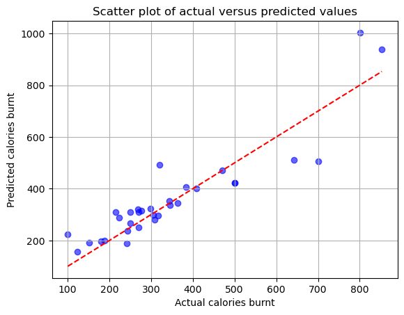

```python
# Create a scatter plot
plt.scatter(y_test, y_pred_lr, color = 'blue', alpha = 0.6)
plt.plot([min(y_test), max(y_test)], [min(y_test), max(y_test)], color='red', linestyle='--')
plt.title('Scatter plot of actual versus predicted values')
plt.xlabel('Actual calories burnt')
plt.ylabel('Predicted calories burnt')
plt.grid()
plt.show()
```

### Comments

The above scatter plot shows how closely the predicted values align with the actual values of calories burnt. The dashed red line represents the ideal scenario where the predicted values perfectly match the actual values. This line is at a 45-degree angle, meaning that if a point lies on this line, the predicted and actual values are the same. Many of the blue points are close to the dashed red line, which indicates that the model performs reasonably well in predicting calories burnt for most data points, suggesting that the model can generalize well to the data.

In general, since the points are generally scattered around the red line, I can conclude that the linear regression model has good predictive capabilities.

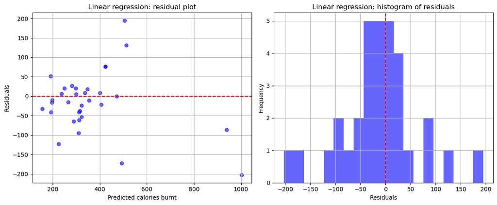

```python
# Calculate residuals
residuals = y_test - y_pred_lr

# Create subplots
plt.figure(figsize=(12, 5))

# Residual plot
plt.subplot(1, 2, 1)
plt.scatter(y_pred_lr, residuals, color = 'blue', alpha = 0.6)
plt.axhline(y = 0, color = 'red', linestyle = '--')
plt.title('Linear regression: residual plot')
plt.xlabel('Predicted calories burnt')
plt.ylabel('Residuals')
plt.grid()

# Histogram of residuals
plt.subplot(1, 2, 2)
plt.hist(residuals, bins = 20, color = 'blue', alpha = 0.6)
plt.axvline(x = 0, color = 'red', linestyle = '--')
plt.title('Linear regression: histogram of residuals')
plt.xlabel('Residuals')
plt.ylabel('Frequency')
plt.grid()

# Show the plots
plt.tight_layout()
plt.show()
```

### Comments

Residuals are the differences between the actual values and the predicted values generated by a regression model.

Summary

The residual plot and histogram together suggest that the linear regression model is fairly appropriate for this data, but there may be outliers or certain regions where the model underperforms.